## Rossman Store Sales Regression Prediction

#### 背景介绍

Rossmann在7个欧洲国家经营着3,000多家药店。目前，Rossmann商店经理的任务是预先提前六周预测他们的日常销售。商店销售受许多因素的影响，包括促销，竞争，学校和州假日，季节性和地方性。成千上万的个体经理根据他们独特的情况预测销售情况，结果的准确性可能会有很大差异。本次项目要求预测德国各地的1,115家商店6周中每周销售额

#### 数据集描述

数据以1115家Rossmann连锁商店为研究对象，从2013年1月1日到2015年7月共计录1017209条销售数据（27个特征）。我们可以从kaggle的rossmann销售竞赛的data页面获取到我们项目所需的数据集，这个数据集一共涵盖了四个文件:

- train.csv - 含有销量的历史数据
- test.csv - 未含销量的历史数据
- sample_submission.csv - 以正确格式提交的示例文件
- store.csv - 关于每个商店的一些补充信息

#### 各特征描述

- Id - 表示测试集中的（存储，日期）重复的Id
- Store- 每家商店的唯一ID
- Sales - 任何一天的营业额（这是您预测的）
- Customers- 特定日期的客户数量
- Open - 商店是否营业的指标：0 =关闭，1 =打开
- StateHoliday - 表示州假日。通常情况下，除了少数例外，所有商店都会在州假期关闭。请注意，所有学校在公众假期和周末都关闭。a =公共假日，b =复活节假期，c =圣诞节，0 =无
- SchoolHoliday - 表示（商店，日期）是否受到公立学校关闭的影响
- StoreType - 区分4种不同的商店模型：a，b，c，d
- Assortment- 描述分类级别：a =基本，b =额外，c =扩展
- CompetitionDistance - 距离最近的竞争对手商店的距离（以米为单位）
- CompetitionOpenSince [Month / Year] - 给出最接近的竞争对手开放时间的大致年份和月份
- Promo- 指示商店当天是否正在运营促销
- Promo2 - Promo2是一些商店的持续和连续促销：0 =商店不参与，1 =商店参与
- Promo2Since [年/周] - 描述商店开始参与Promo2的年份和日历周
- PromoInterval - 描述Promo2启动的连续间隔，命名重新开始促销的月份。例如，“2月，5月，8月，11月”意味着每一轮在该商店的任何给定年份的2月，5月，8月和11月开始

```python
#导入各个包
import pandas as pd
import numpy as np
import matplotlib.pyplot as plt
import seaborn as sns
plt.style.use('ggplot')
%matplotlib inline

plt.rcParams['font.sans-serif'] = ['SimHei']
plt.rcParams['font.serif'] = ['SimHei']
plt.rcParams['figure.dpi'] = 500 #分辨率
plt.rcParams['axes.unicode_minus'] = False # 解决保存图像是负号'-'显示为方块的问题,或者转换负号为字符串
```

```python
#读入train test store文件中的数据
data_train = pd.read_csv('train.csv',encoding = 'gb18030')
data_test = pd.read_csv('test.csv',encoding = 'gb18030')
data_store = pd.read_csv('store.csv',encoding = 'gb18030')
```

```python
#查看各个数据集的信息
def check_file(data,data_name):
    print('{:*^60}'.format('{}前5行').format(data_name))
    print(data.head(5))
    print('{:*^60}'.format('{}各行信息').format(data_name))
    print(data.info(),'\n','\n')
data_to_show = [data_store,data_train,data_test]
data_to_show_names = ['data_store','data_train','data_test']

for data,data_name in zip(data_to_show,data_to_show_names):
    check_file(data,data_name)
```

```
***************************data_store前5行****************************
   Store StoreType Assortment  CompetitionDistance  CompetitionOpenSinceMonth  \
0      1         c          a               1270.0                        9.0
1      2         a          a                570.0                       11.0
2      3         a          a              14130.0                       12.0
3      4         c          c                620.0                        9.0
4      5         a          a              29910.0                        4.0

   CompetitionOpenSinceYear  Promo2  Promo2SinceWeek  Promo2SinceYear  \
0                    2008.0       0              NaN              NaN
1                    2007.0       1             13.0           2010.0
2                    2006.0       1             14.0           2011.0
3                    2009.0       0              NaN              NaN
4                    2015.0       0              NaN              NaN

     PromoInterval
0              NaN
1  Jan,Apr,Jul,Oct
2  Jan,Apr,Jul,Oct
3              NaN
4              NaN
***************************data_store各行信息***************************
<class 'pandas.core.frame.DataFrame'>
RangeIndex: 1115 entries, 0 to 1114
Data columns (total 10 columns):
Store                        1115 non-null int64
StoreType                    1115 non-null object
Assortment                   1115 non-null object
CompetitionDistance          1112 non-null float64
CompetitionOpenSinceMonth    761 non-null float64
CompetitionOpenSinceYear     761 non-null float64
Promo2                       1115 non-null int64
Promo2SinceWeek              571 non-null float64
Promo2SinceYear              571 non-null float64
PromoInterval                571 non-null object
dtypes: float64(5), int64(2), object(3)
memory usage: 87.2+ KB
None


```

[output cut: 39 more lines]

```
***************************data_test各行信息***************************
<class 'pandas.core.frame.DataFrame'>
RangeIndex: 41088 entries, 0 to 41087
Data columns (total 8 columns):
Id               41088 non-null int64
Store            41088 non-null int64
DayOfWeek        41088 non-null int64
Date             41088 non-null object
Open             41077 non-null float64
Promo            41088 non-null int64
StateHoliday     41088 non-null object
SchoolHoliday    41088 non-null int64
dtypes: float64(1), int64(5), object(2)
memory usage: 2.5+ MB
None
```

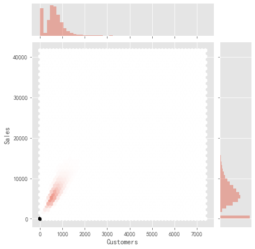

```python
#顾客数与销售额的关系，即使销售额已经被我们删除，但我们仍想观察下他们两者之间的关系，可以采用二元变量分布图
fig = plt.figure(figsize=(20,10))
sns.jointplot(x=data_train['Customers'],y=data_train['Sales'],kind = 'hex')
```

```python
#观察train.csv 和test.csv发现 test.csv中没有 customers 这一列，所以customers带入到训练集训练,而测试集无法根据该特征进行预测，所以在data_train中删除这一列
data_train = data_train.drop(['Customers'],axis = 1)
data.head(5)
```

|  | Id | Store | DayOfWeek | Date | Open | Promo | StateHoliday | SchoolHoliday |
| --- | --- | --- | --- | --- | --- | --- | --- | --- |
| 0 | 1 | 1 | 4 | 2015-09-17 | 1.0 | 1 | 0 | 0 |
| 1 | 2 | 3 | 4 | 2015-09-17 | 1.0 | 1 | 0 | 0 |
| 2 | 3 | 7 | 4 | 2015-09-17 | 1.0 | 1 | 0 | 0 |
| 3 | 4 | 8 | 4 | 2015-09-17 | 1.0 | 1 | 0 | 0 |
| 4 | 5 | 9 | 4 | 2015-09-17 | 1.0 | 1 | 0 | 0 |

```python
#检查数据表，查看数据表中是否有一些人为导致的错误
def check_unique(data):
    for column in data.columns:
        print('{}不重复值的个数为:'.format(column),len(data[column].unique()))
```

```python
#检查store表
check_unique(data_store)
```

```
Store不重复值的个数为: 1115
StoreType不重复值的个数为: 4
Assortment不重复值的个数为: 3
CompetitionDistance不重复值的个数为: 655
CompetitionOpenSinceMonth不重复值的个数为: 13
CompetitionOpenSinceYear不重复值的个数为: 24
Promo2不重复值的个数为: 2
Promo2SinceWeek不重复值的个数为: 25
Promo2SinceYear不重复值的个数为: 8
PromoInterval不重复值的个数为: 4
```

```python
#检查发现‘CompetitionOpenSinceMonth’有13个
np.sort(data_store['CompetitionOpenSinceMonth'].unique())
```

```
array([ 1.,  2.,  3.,  4.,  5.,  6.,  7.,  8.,  9., 10., 11., 12., nan])
```

```python
#检查‘CompetitionOpenSinceYear’列
np.sort(data_store['CompetitionOpenSinceYear'].unique())
```

```
array([1900., 1961., 1990., 1994., 1995., 1998., 1999., 2000., 2001.,
       2002., 2003., 2004., 2005., 2006., 2007., 2008., 2009., 2010.,
       2011., 2012., 2013., 2014., 2015.,   nan])
```

```python
#检查test表
check_unique(data_test)
```

```
Id不重复值的个数为: 41088
Store不重复值的个数为: 856
DayOfWeek不重复值的个数为: 7
Date不重复值的个数为: 48
Open不重复值的个数为: 3
Promo不重复值的个数为: 2
StateHoliday不重复值的个数为: 2
SchoolHoliday不重复值的个数为: 2
```

```python
#检查train表
check_unique(data_train)
```

```
Store不重复值的个数为: 1115
DayOfWeek不重复值的个数为: 7
Date不重复值的个数为: 942
Sales不重复值的个数为: 21734
Open不重复值的个数为: 2
Promo不重复值的个数为: 2
StateHoliday不重复值的个数为: 5
SchoolHoliday不重复值的个数为: 2
```

```python
#检查发现'StateHoliday'中有5个值，对其进行更深入的检查
data_train['StateHoliday'].unique()
#发现有字符型的0和数值型的0，需要对其重新调整
ajust = {'0':'None',0:'None','a':'public_holiday','b':'Easter','c':'Christmas'}
data_train['StateHoliday']=data_train['StateHoliday'].map(ajust)
```

```python
data_train['StateHoliday'].unique()
```

```
array(['None', 'public_holiday', 'Easter', 'Christmas'], dtype=object)
```

```python
#检查‘SchoolHoliday'中的值
data_train['SchoolHoliday'].unique()
```

```
array([1, 0], dtype=int64)
```

```python
#检查各个数据集是否有空置
print(data_train.isnull().any())
print(data_test.isnull().any())
print(data_store.isnull().any())
```

```
Store            False
DayOfWeek        False
Date             False
Sales            False
Open             False
Promo            False
StateHoliday     False
SchoolHoliday    False
dtype: bool
Id               False
Store            False
DayOfWeek        False
Date             False
Open              True
Promo            False
StateHoliday     False
SchoolHoliday    False
dtype: bool
Store                        False
StoreType                    False
Assortment                   False
CompetitionDistance           True
CompetitionOpenSinceMonth     True
CompetitionOpenSinceYear      True
Promo2                       False
Promo2SinceWeek               True
Promo2SinceYear               True
PromoInterval                 True
dtype: bool
```

```python
#发现data_test中的‘open’有缺失，以及竞争对手距离信息等有缺失，并且促销的相关信息也有缺失，可能是因为Promo2为0所导致的，我们需要对这些信息进行处理和检查
def check_null_ajacent(data,columns):
    null_indexes = []
    null_indexes_length = []
    for column in columns:
        index = data[data[column].isnull()].index
        null_indexes.append(index)
        null_indexes_length.append(len(index))
    flag = 1
    for i in range(len(null_indexes)-1):
        if set(null_indexes[i])!= set(null_indexes[i+1]):
            flag = 0
    if(flag == 1):
        print('所有缺失的行index相同')
    else:
        for i in range(len(null_indexes_length)):
            print(null_indexes_length[i],'\t')
    return null_indexes
```

```python
#对竞争信息为空的验证
check_1 = check_null_ajacent(data_store,['CompetitionDistance','CompetitionOpenSinceMonth','CompetitionOpenSinceYear'])
```

```
3
354
354
```

从上述结果可以看出竞争对手的距离大部分没有缺失，但是竞争对手的开始月份和开始年份有缺失

```python
#从上述结果可以看出竞争对手的距离大部分没有缺失，但是竞争对手的开始月份和开始年份有缺失，查看竞争开始的年份和月份缺少的行是否相同
check_2 = check_null_ajacent(data_store,['CompetitionOpenSinceMonth','CompetitionOpenSinceYear'])
```

```
所有缺失的行index相同
```

```python
#观察CompetitionDistance为空的情况
data_store.iloc[check_1[0]]
```

|  | Store | StoreType | Assortment | CompetitionDistance | CompetitionOpenSinceMonth | CompetitionOpenSinceYear | Promo2 | Promo2SinceWeek | Promo2SinceYear | PromoInterval |
| --- | --- | --- | --- | --- | --- | --- | --- | --- | --- | --- |
| 290 | 291 | d | a | NaN | NaN | NaN | 0 | NaN | NaN | NaN |
| 621 | 622 | a | c | NaN | NaN | NaN | 0 | NaN | NaN | NaN |
| 878 | 879 | d | a | NaN | NaN | NaN | 1 | 5.0 | 2013.0 | Feb,May,Aug,Nov |

根据以上分析得出结论，除了没有竞争对手（即同时没有竞争开始年份月份）的情况，其余的情况应该是有竞争对手但竞争开始年月份没有相应的记录

```python
#再查看促销的缺失情况是否缺失的行标是相同的
check3 = check_null_ajacent(data_store,['Promo2SinceWeek','Promo2SinceYear','PromoInterval'])
```

```
所有缺失的行index相同
```

```python
#检查空值行所对应的‘Promo2’是否也为空
sum(data_store.iloc[check3[0]]['Promo2'] == 1)
```

```
0
```

```python
#将data_train和data_test分别与data_store横向连接，补充特征
data_train_complete = pd.merge(data_train,data_store,on='Store',how = 'left')
data_test_complete = pd.merge(data_test,data_store,on='Store',how = 'left')
#将data_train和data_test竖向拼接，以便后续特征工程操作一致
data_train_test_complete = pd.concat([data_train_complete,data_test_complete.drop('Id',axis =1)],axis=0,ignore_index = True)
```

```python
#查看data_train_complete前5行
data_train_complete.head(5)
```

|  | Store | DayOfWeek | Date | Sales | Open | Promo | StateHoliday | SchoolHoliday | StoreType | Assortment | CompetitionDistance | CompetitionOpenSinceMonth | CompetitionOpenSinceYear | Promo2 | Promo2SinceWeek | Promo2SinceYear | PromoInterval |
| --- | --- | --- | --- | --- | --- | --- | --- | --- | --- | --- | --- | --- | --- | --- | --- | --- | --- |
| 0 | 1 | 5 | 2015-07-31 | 5263 | 1 | 1 | None | 1 | c | a | 1270.0 | 9.0 | 2008.0 | 0 | NaN | NaN | NaN |
| 1 | 2 | 5 | 2015-07-31 | 6064 | 1 | 1 | None | 1 | a | a | 570.0 | 11.0 | 2007.0 | 1 | 13.0 | 2010.0 | Jan,Apr,Jul,Oct |
| 2 | 3 | 5 | 2015-07-31 | 8314 | 1 | 1 | None | 1 | a | a | 14130.0 | 12.0 | 2006.0 | 1 | 14.0 | 2011.0 | Jan,Apr,Jul,Oct |
| 3 | 4 | 5 | 2015-07-31 | 13995 | 1 | 1 | None | 1 | c | c | 620.0 | 9.0 | 2009.0 | 0 | NaN | NaN | NaN |
| 4 | 5 | 5 | 2015-07-31 | 4822 | 1 | 1 | None | 1 | a | a | 29910.0 | 4.0 | 2015.0 | 0 | NaN | NaN | NaN |

```python
#查看data_test_complete前5行
data_test_complete.head(5)
```

|  | Id | Store | DayOfWeek | Date | Open | Promo | StateHoliday | SchoolHoliday | StoreType | Assortment | CompetitionDistance | CompetitionOpenSinceMonth | CompetitionOpenSinceYear | Promo2 | Promo2SinceWeek | Promo2SinceYear | PromoInterval |
| --- | --- | --- | --- | --- | --- | --- | --- | --- | --- | --- | --- | --- | --- | --- | --- | --- | --- |
| 0 | 1 | 1 | 4 | 2015-09-17 | 1.0 | 1 | 0 | 0 | c | a | 1270.0 | 9.0 | 2008.0 | 0 | NaN | NaN | NaN |
| 1 | 2 | 3 | 4 | 2015-09-17 | 1.0 | 1 | 0 | 0 | a | a | 14130.0 | 12.0 | 2006.0 | 1 | 14.0 | 2011.0 | Jan,Apr,Jul,Oct |
| 2 | 3 | 7 | 4 | 2015-09-17 | 1.0 | 1 | 0 | 0 | a | c | 24000.0 | 4.0 | 2013.0 | 0 | NaN | NaN | NaN |
| 3 | 4 | 8 | 4 | 2015-09-17 | 1.0 | 1 | 0 | 0 | a | a | 7520.0 | 10.0 | 2014.0 | 0 | NaN | NaN | NaN |
| 4 | 5 | 9 | 4 | 2015-09-17 | 1.0 | 1 | 0 | 0 | a | c | 2030.0 | 8.0 | 2000.0 | 0 | NaN | NaN | NaN |

```python
#将两个表的日期进行转化
data_train_complete.Date = pd.to_datetime(data_train_complete.Date)
data_test_complete.Date = pd.to_datetime(data_test_complete.Date)
```

### 一、对数据进行可视化分析

相比繁重冗长的表格数据，往往有十几列几百上千行，用人眼根本无法很好的捕捉数据的特性，而使用一些规定指标（方差，标准差，分位点，相关性等）又往往难以直观的理解数据。数据可视化是指以饼状图等图形的方式展示数据。这帮助用户能够更快地识别模式

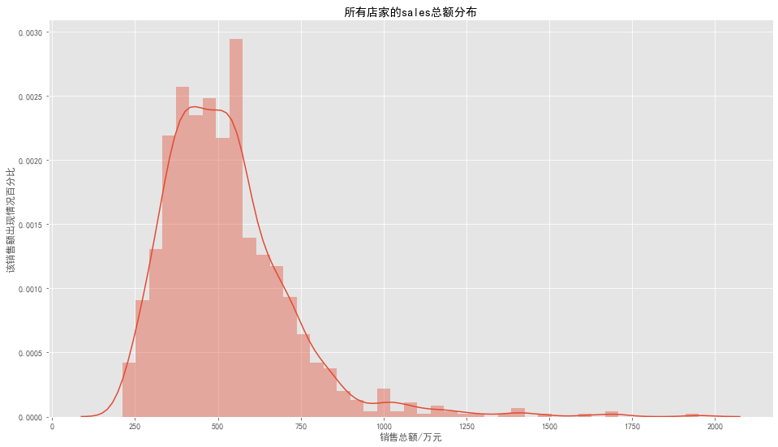

```python
#查看所有店家的Sales分布情况
data1 = data_train_complete.groupby('Store')['Sales'].sum()/10000
plt.figure(figsize=(16,9))
sns.distplot(data1)
plt.title('所有店家的sales总额分布')
plt.xlabel('销售总额/万元')
plt.ylabel('该销售额出现情况百分比')
```

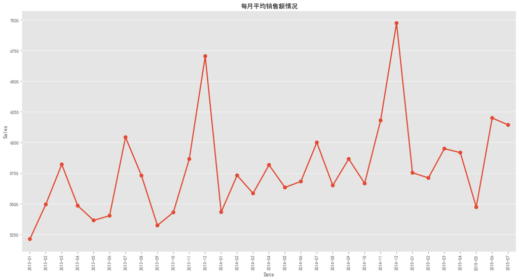

```python
#查看不同日期对于销售额是否有影响
data2 = data_train_complete.groupby('Date')['Sales'].mean().resample('M',kind='period').mean().reset_index()
fig = plt.figure(figsize=(20,10))
ax = fig.add_subplot(1,1,1)
sns.pointplot(data=data2,x='Date',y='Sales',ax = ax)
plt.xticks(rotation = 90)
ax.set_title('每月平均销售额情况')
```

从以上的图中可以得出结论销售额在11月到12月之间具有较大增幅

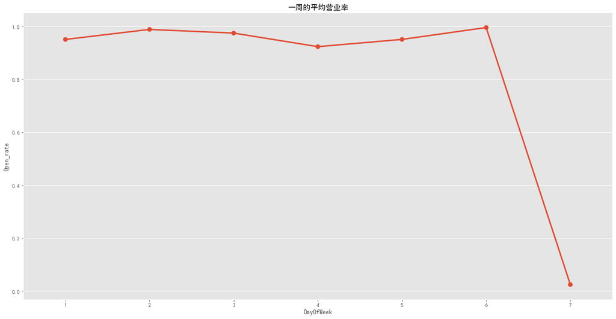

```python
#一周的平均营业率
data3 = data_train_complete.groupby('DayOfWeek')['Open'].mean().reset_index().rename(columns={'Open':'Open_rate'})
fig = plt.figure(figsize=(20,10))
sns.pointplot(data = data3,x='DayOfWeek',y='Open_rate')
plt.title('一周的平均营业率')
```

可见在国外，商店一般在周日不营业

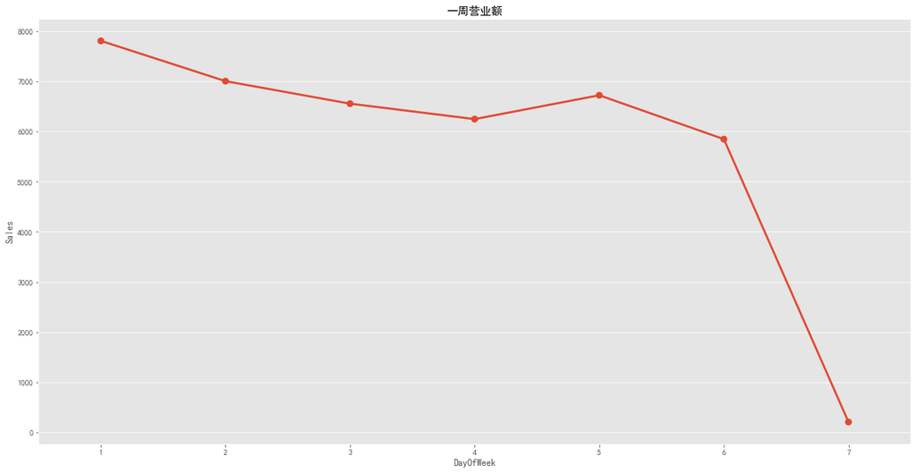

```python
#查看一周的平均营业额
data4 = data_train_complete.groupby('DayOfWeek')['Sales'].mean().reset_index()
fig = plt.figure(figsize=(20,10))
sns.pointplot(data = data4,x = 'DayOfWeek',y = 'Sales')
plt.title('一周营业额')
```

从上图中得出结论，一周营业额和营业率具有相关性，不营业当天也不会有营业额，符合实际情况

```python
#查看不同年各个月份的平均销售情况
data_train_complete['year'] = data_train_complete.Date.map(lambda x:x.year)
data_train_complete['month'] = data_train_complete.Date.map(lambda x:x.month)
data_train_complete['day'] = data_train_complete.Date.map(lambda x:x.day)
```

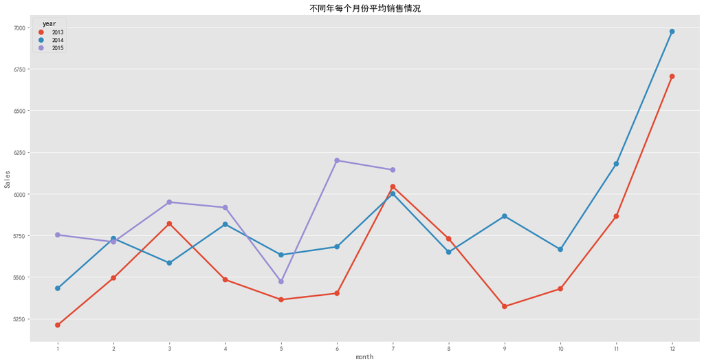

```python
data5=data_train_complete.Sales.groupby([data_train_complete.year,data_train_complete.month]).mean().reset_index()
fig=plt.figure(figsize=(20,10))
ax=fig.add_subplot(1,1,1)
ax.set_title('不同年每个月份平均销售情况')
sns.pointplot(x='month',y='Sales',hue='year',data=data5,ax=ax)
```

根据以上图表，依然能够反映出，在每年11月-12月销售额有很大的提升

```
No handles with labels found to put in legend.
```

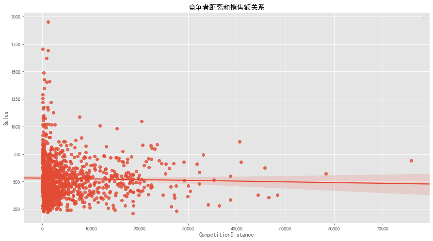

```python
#探索竞争者的距离与销售额之间的关系
data6 = data_train_complete.groupby('Store')['CompetitionDistance','Sales'].agg({'CompetitionDistance':'mean','Sales':'sum'})
data6['Sales'] = data6['Sales'].map(lambda x:x/10000)
fig=plt.figure(figsize=(15,8))
ax=fig.add_subplot(1,1,1)
sns.regplot(x='CompetitionDistance',y='Sales',data=data6,ax=ax)
ax.set_title('竞争者距离和销售额关系')
plt.legend(loc='best')
```

从以上图中可以看出，在竞争者距离比较近的时候，销售额分布范围比较大

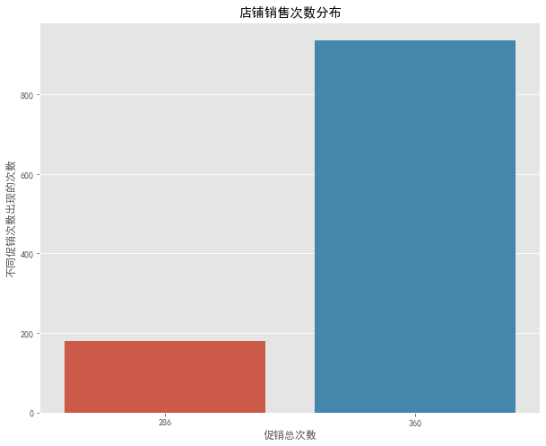

```python
#查看各个店铺的促销次数分布
data7 = data_train_complete.groupby('Store')['Promo'].sum()
data7 = data7.value_counts()
fig = plt.figure(figsize = (10,8))
sns.barplot(data7.index,data7.values)
plt.title('店铺销售次数分布')
plt.xlabel('促销总次数')
plt.ylabel('不同促销次数出现的次数')
```

从以上图中可以看出，销售总次数一共有两种，所以一共有两种销售策略

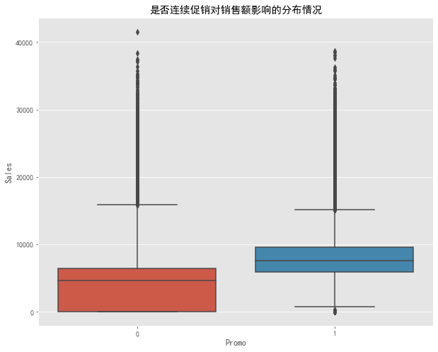

```python
#查看促销对销售额的影响
fig=plt.figure(figsize = (10,8))
ax=fig.add_subplot(1,1,1)
sns.boxplot(y='Sales',x='Promo',data=data_train_complete,ax=ax)
ax.set_title('是否连续促销对销售额影响的分布情况')
```

从上图可以看出，采取促销活动的销售额普遍要高一些

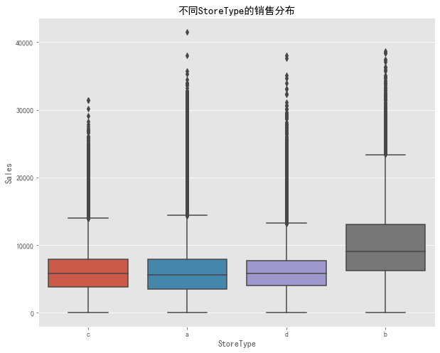

```python
#探索不同商店类型的销售额
fig = plt.figure(figsize=(10,8))
#不同StoreType的销售分布
sns.boxplot(y = 'Sales',x = 'StoreType',data= data_train_complete)
plt.title('不同StoreType的销售分布')
```

从以上我们可以看到b类型的商店销售额更高一些

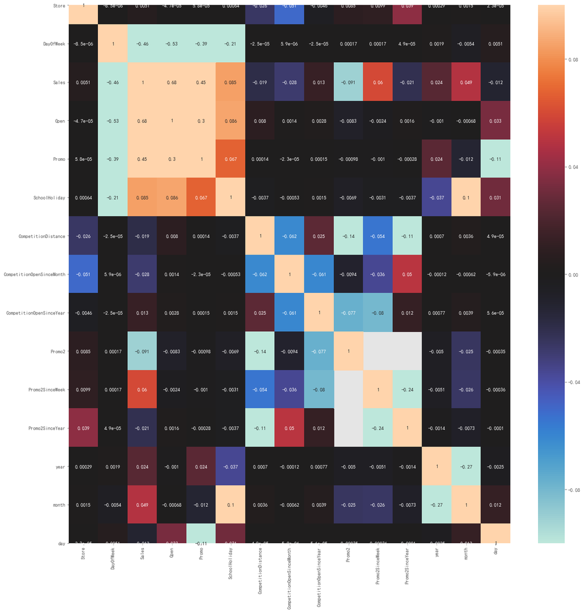

```python
#查看各个特值之间的相互关联，用热力图显示
fig = plt.figure(figsize = (20,20))
sns.heatmap(data_train_complete.corr(),annot = True,vmin = -0.1,vmax =0.1,center = 0)
```

### 二、特征工程

机器学习的特征工程是将原始的输入数据转换成特征，以便于更好的表示潜在的问题，并有助于提高预测模型准确性的过程。 找出合适的特征是很困难且耗时的工作，它需要专家知识，而应用机器学习基本也可以理解成特征工程。但是，特征工程对机器学习模型的应用有很大影响，有句俗话叫做“数据和特征决定了机器学习模型的性能上限”。

- 处理空值
- 数据类型转换
- 独热编码

```python
#查看data_train_test_complete的前5行
data_train_test_complete.head(5)
```

|  | Assortment | CompetitionDistance | CompetitionOpenSinceMonth | CompetitionOpenSinceYear | Date | DayOfWeek | Open | Promo | Promo2 | Promo2SinceWeek | Promo2SinceYear | PromoInterval | Sales | SchoolHoliday | StateHoliday | Store | StoreType |
| --- | --- | --- | --- | --- | --- | --- | --- | --- | --- | --- | --- | --- | --- | --- | --- | --- | --- |
| 0 | a | 1270.0 | 9.0 | 2008.0 | 2015-07-31 | 5 | 1.0 | 1 | 0 | NaN | NaN | NaN | 5263.0 | 1 | None | 1 | c |
| 1 | a | 570.0 | 11.0 | 2007.0 | 2015-07-31 | 5 | 1.0 | 1 | 1 | 13.0 | 2010.0 | Jan,Apr,Jul,Oct | 6064.0 | 1 | None | 2 | a |
| 2 | a | 14130.0 | 12.0 | 2006.0 | 2015-07-31 | 5 | 1.0 | 1 | 1 | 14.0 | 2011.0 | Jan,Apr,Jul,Oct | 8314.0 | 1 | None | 3 | a |
| 3 | c | 620.0 | 9.0 | 2009.0 | 2015-07-31 | 5 | 1.0 | 1 | 0 | NaN | NaN | NaN | 13995.0 | 1 | None | 4 | c |
| 4 | a | 29910.0 | 4.0 | 2015.0 | 2015-07-31 | 5 | 1.0 | 1 | 0 | NaN | NaN | NaN | 4822.0 | 1 | None | 5 | a |

```python
#将时间类型进行转化
data_train_test_complete.Date = pd.to_datetime(data_train_test_complete.Date)
```

```python
#将日期分解为年，月，日
data_train_test_complete['year'] = data_train_test_complete.Date.map(lambda x:x.year)
data_train_test_complete['month'] = data_train_test_complete.Date.map(lambda x:x.month)
data_train_test_complete['day'] = data_train_test_complete.Date.map(lambda x:x.day)
data_train_test_complete['Date'] = data_train_test_complete.Date.map(lambda x:x.date())
```

```python
#检查空值
data_train_test_complete.isnull().any()
```

```
Assortment                   False
CompetitionDistance           True
CompetitionOpenSinceMonth     True
CompetitionOpenSinceYear      True
Date                         False
DayOfWeek                    False
Open                          True
Promo                        False
Promo2                       False
Promo2SinceWeek               True
Promo2SinceYear               True
PromoInterval                 True
Sales                         True
SchoolHoliday                False
StateHoliday                 False
Store                        False
StoreType                    False
year                         False
month                        False
day                          False
dtype: bool
```

```python
#查看Open的缺失情况
data_train_test_complete[data_train_test_complete.Open.isnull()]
```

|  | Assortment | CompetitionDistance | CompetitionOpenSinceMonth | CompetitionOpenSinceYear | Date | DayOfWeek | Open | Promo | Promo2 | Promo2SinceWeek | Promo2SinceYear | PromoInterval | Sales | SchoolHoliday | StateHoliday | Store | StoreType | year | month | day |
| --- | --- | --- | --- | --- | --- | --- | --- | --- | --- | --- | --- | --- | --- | --- | --- | --- | --- | --- | --- | --- |
| 1017688 | c | NaN | NaN | NaN | 2015-09-17 | 4 | NaN | 1 | 0 | NaN | NaN | NaN | NaN | 0 | 0 | 622 | a | 2015 | 9 | 17 |
| 1018544 | c | NaN | NaN | NaN | 2015-09-16 | 3 | NaN | 1 | 0 | NaN | NaN | NaN | NaN | 0 | 0 | 622 | a | 2015 | 9 | 16 |
| 1019400 | c | NaN | NaN | NaN | 2015-09-15 | 2 | NaN | 1 | 0 | NaN | NaN | NaN | NaN | 0 | 0 | 622 | a | 2015 | 9 | 15 |
| 1020256 | c | NaN | NaN | NaN | 2015-09-14 | 1 | NaN | 1 | 0 | NaN | NaN | NaN | NaN | 0 | 0 | 622 | a | 2015 | 9 | 14 |
| 1021968 | c | NaN | NaN | NaN | 2015-09-12 | 6 | NaN | 0 | 0 | NaN | NaN | NaN | NaN | 0 | 0 | 622 | a | 2015 | 9 | 12 |
| 1022824 | c | NaN | NaN | NaN | 2015-09-11 | 5 | NaN | 0 | 0 | NaN | NaN | NaN | NaN | 0 | 0 | 622 | a | 2015 | 9 | 11 |
| 1023680 | c | NaN | NaN | NaN | 2015-09-10 | 4 | NaN | 0 | 0 | NaN | NaN | NaN | NaN | 0 | 0 | 622 | a | 2015 | 9 | 10 |
| 1024536 | c | NaN | NaN | NaN | 2015-09-09 | 3 | NaN | 0 | 0 | NaN | NaN | NaN | NaN | 0 | 0 | 622 | a | 2015 | 9 | 9 |
| 1025392 | c | NaN | NaN | NaN | 2015-09-08 | 2 | NaN | 0 | 0 | NaN | NaN | NaN | NaN | 0 | 0 | 622 | a | 2015 | 9 | 8 |
| 1026248 | c | NaN | NaN | NaN | 2015-09-07 | 1 | NaN | 0 | 0 | NaN | NaN | NaN | NaN | 0 | 0 | 622 | a | 2015 | 9 | 7 |
| 1027960 | c | NaN | NaN | NaN | 2015-09-05 | 6 | NaN | 0 | 0 | NaN | NaN | NaN | NaN | 0 | 0 | 622 | a | 2015 | 9 | 5 |

从表中可以看出Open为Null的都是Store 622，我们可以观察在Open为Null的时间内，其他店的营业情况

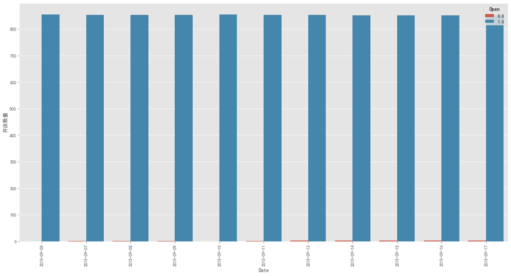

```python
date_open_null = data_train_test_complete[data_train_test_complete.Open.isnull()].Date
data_date_open_null = data_train_test_complete[data_train_test_complete.Date.isin(date_open_null)]

data8 = data_date_open_null.groupby(['Date','Open'])['Store'].count().rename("开店数量").reset_index()
fig = plt.figure(figsize = (20,10))
sns.barplot(x='Date',y='开店数量',hue = 'Open',data = data8)
plt.xticks(rotation = 90)
```

从上图中可以看出在Store622店Open为Null的时间，其他店绝大多数都是营业的，因此我们可以填补Null值为1

```python
index_open_null = data_train_test_complete[data_train_test_complete.Open.isnull()].index
data_train_test_complete.loc[index_open_null,'Open'] = 1
```

```python
#检查每列缺失值的个数
print(data_store.isnull().sum(axis = 0))
#查看缺失值所占的比例
print(round(data_store.isnull().sum(axis = 0)/len(data_store),3))
```

```
Store                          0
StoreType                      0
Assortment                     0
CompetitionDistance            3
CompetitionOpenSinceMonth    354
CompetitionOpenSinceYear     354
Promo2                         0
Promo2SinceWeek              544
Promo2SinceYear              544
PromoInterval                544
dtype: int64
Store                        0.000
StoreType                    0.000
Assortment                   0.000
CompetitionDistance          0.003
CompetitionOpenSinceMonth    0.317
CompetitionOpenSinceYear     0.317
Promo2                       0.000
Promo2SinceWeek              0.488
Promo2SinceYear              0.488
PromoInterval                0.488
dtype: float64
```

```python
#确定所有空特征
missing_columns = data_store.columns[data_store.isnull().sum()!= 0].tolist()
#查看这些列与Sales之间的关系
data_store_tem = pd.concat([data_train_test_complete[missing_columns],
                            data_train_test_complete.Sales],axis = 1)
#查看各个特征与Sales的协方差
data_store_tem.corr
```

```
<bound method DataFrame.corr of          CompetitionDistance  CompetitionOpenSinceMonth  \
0                     1270.0                        9.0
1                      570.0                       11.0
2                    14130.0                       12.0
3                      620.0                        9.0
4                    29910.0                        4.0
...                      ...                        ...
1058292               1900.0                        6.0
1058293               1880.0                        4.0
1058294               9260.0                        NaN
1058295                870.0                        NaN
1058296               5350.0                        NaN

         CompetitionOpenSinceYear  Promo2SinceWeek  Promo2SinceYear  \
0                          2008.0              NaN              NaN
```

[output cut: 25 more lines]

```python
#备份数据
data_backups = data_train_test_complete
#对于竞争者距离填充平均数
data_train_test_complete.CompetitionDistance=data_train_test_complete.CompetitionDistance.fillna(data_train_test_complete.CompetitionDistance.mean())
#其余特征做众数填充
for column in missing_columns:
    data_train_test_complete[column] = data_train_test_complete[column].fillna(data_train_test_complete[column].mode()[0])
data_train_test_complete.isnull().any()
```

```
Assortment                   False
CompetitionDistance          False
CompetitionOpenSinceMonth    False
CompetitionOpenSinceYear     False
Date                         False
DayOfWeek                    False
Open                         False
Promo                        False
Promo2                       False
Promo2SinceWeek              False
Promo2SinceYear              False
PromoInterval                False
Sales                         True
SchoolHoliday                False
StateHoliday                 False
Store                        False
StoreType                    False
year                         False
month                        False
day                          False
dtype: bool
```

```python
data_train_test_complete.dtypes
```

```
Assortment                    object
CompetitionDistance          float64
CompetitionOpenSinceMonth    float64
CompetitionOpenSinceYear     float64
Date                          object
DayOfWeek                      int64
Open                         float64
Promo                          int64
Promo2                         int64
Promo2SinceWeek              float64
Promo2SinceYear              float64
PromoInterval                 object
Sales                        float64
SchoolHoliday                  int64
StateHoliday                  object
Store                          int64
StoreType                     object
year                           int64
month                          int64
day                            int64
dtype: object
```

```python
#将浮点数转化为整型，类似于开始年份及开始月份，以及是否营业等信息应该为整型的数，这样后面好进行独热编码
def convert_to_int(data,columns):
    for column in columns:
        data[column] = data[column].astype(np.int64)
    return data
columns_covert_int = ['Open','CompetitionOpenSinceMonth','CompetitionOpenSinceYear',
                      'Promo2SinceWeek','Promo2SinceYear']
data_train_test_complete = convert_to_int(data_train_test_complete,columns_covert_int)
data_train_test_complete.dtypes
```

```
Assortment                    object
CompetitionDistance          float64
CompetitionOpenSinceMonth      int64
CompetitionOpenSinceYear       int64
Date                          object
DayOfWeek                      int64
Open                           int64
Promo                          int64
Promo2                         int64
Promo2SinceWeek                int64
Promo2SinceYear                int64
PromoInterval                 object
Sales                        float64
SchoolHoliday                  int64
StateHoliday                  object
Store                          int64
StoreType                     object
year                           int64
month                          int64
day                            int64
dtype: object
```

```python
#对于一些int值的特征，其实并非连续型的变量，而是离散型变量，需先对其转化为字符型(object型)，然后再进行独热编码
def convert_to_str(data,columns):
    for column in columns:
        data[column] = data[column].astype(np.str)
    return data
columns_convert_str = ['DayOfWeek','CompetitionOpenSinceMonth','CompetitionOpenSinceYear',
                       'Promo2SinceWeek','Promo2SinceYear','year','month','day']
data_train_test_complete = convert_to_str(data_train_test_complete,columns_convert_str)
```

```python
data_train_test_complete.dtypes
```

```
Assortment                    object
CompetitionDistance          float64
CompetitionOpenSinceMonth     object
CompetitionOpenSinceYear      object
Date                          object
DayOfWeek                     object
Open                           int64
Promo                          int64
Promo2                         int64
Promo2SinceWeek               object
Promo2SinceYear               object
PromoInterval                 object
Sales                        float64
SchoolHoliday                  int64
StateHoliday                  object
Store                          int64
StoreType                     object
year                          object
month                         object
day                           object
dtype: object
```

```python
#将object型的特征独热编码，转化为0，1的二值型特征
dummies_columns = list(data_train_test_complete.dtypes[data_train_test_complete.dtypes == 'object']
                       .drop(['Date']).index)
data_train_test_complete = pd.get_dummies(data_train_test_complete,columns = dummies_columns)
pd.set_option('display.max_columns', None)
data_train_test_complete.head(5)
```

|  | CompetitionDistance | Date | Open | Promo | Promo2 | Sales | SchoolHoliday | Store | Assortment_a | Assortment_b | Assortment_c | CompetitionOpenSinceMonth_1 | CompetitionOpenSinceMonth_10 | CompetitionOpenSinceMonth_11 | CompetitionOpenSinceMonth_12 | CompetitionOpenSinceMonth_2 | CompetitionOpenSinceMonth_3 | CompetitionOpenSinceMonth_4 | CompetitionOpenSinceMonth_5 | CompetitionOpenSinceMonth_6 | CompetitionOpenSinceMonth_7 | CompetitionOpenSinceMonth_8 | CompetitionOpenSinceMonth_9 | CompetitionOpenSinceYear_1900 | CompetitionOpenSinceYear_1961 | CompetitionOpenSinceYear_1990 | CompetitionOpenSinceYear_1994 | CompetitionOpenSinceYear_1995 | CompetitionOpenSinceYear_1998 | … |
| --- | --- | --- | --- | --- | --- | --- | --- | --- | --- | --- | --- | --- | --- | --- | --- | --- | --- | --- | --- | --- | --- | --- | --- | --- | --- | --- | --- | --- | --- | --- |
| 0 | 1270.0 | 2015-07-31 | 1 | 1 | 0 | 5263.0 | 1 | 1 | 1 | 0 | 0 | 0 | 0 | 0 | 0 | 0 | 0 | 0 | 0 | 0 | 0 | 0 | 1 | 0 | 0 | 0 | 0 | 0 | 0 | … |
| 1 | 570.0 | 2015-07-31 | 1 | 1 | 1 | 6064.0 | 1 | 2 | 1 | 0 | 0 | 0 | 0 | 1 | 0 | 0 | 0 | 0 | 0 | 0 | 0 | 0 | 0 | 0 | 0 | 0 | 0 | 0 | 0 | … |
| 2 | 14130.0 | 2015-07-31 | 1 | 1 | 1 | 8314.0 | 1 | 3 | 1 | 0 | 0 | 0 | 0 | 0 | 1 | 0 | 0 | 0 | 0 | 0 | 0 | 0 | 0 | 0 | 0 | 0 | 0 | 0 | 0 | … |
| 3 | 620.0 | 2015-07-31 | 1 | 1 | 0 | 13995.0 | 1 | 4 | 0 | 0 | 1 | 0 | 0 | 0 | 0 | 0 | 0 | 0 | 0 | 0 | 0 | 0 | 1 | 0 | 0 | 0 | 0 | 0 | 0 | … |
| 4 | 29910.0 | 2015-07-31 | 1 | 1 | 0 | 4822.0 | 1 | 5 | 1 | 0 | 0 | 0 | 0 | 0 | 0 | 0 | 0 | 1 | 0 | 0 | 0 | 0 | 0 | 0 | 0 | 0 | 0 | 0 | 0 | … |

```python
#对数值型的特征进行归一化，使得模型快速收敛
def feature_normalization(data,columns):
    nor_cols=[]
    for column in columns:
        min_col = data[column].min()
        max_col = data[column].max()
        nor_col = data[column].apply(lambda x:(x - min_col)/(max_col - min_col))
        nor_cols.append(nor_col)
    data_concat = pd.concat(nor_cols,axis=1)
    return data_concat

data_train_test_complete.CompetitionDistance =  feature_normalization(data_train_test_complete,
                               ['CompetitionDistance'])
```

```python
data_train_test_complete.head(10)
```

|  | CompetitionDistance | Date | Open | Promo | Promo2 | Sales | SchoolHoliday | Store | Assortment_a | Assortment_b | Assortment_c | CompetitionOpenSinceMonth_1 | CompetitionOpenSinceMonth_10 | CompetitionOpenSinceMonth_11 | CompetitionOpenSinceMonth_12 | CompetitionOpenSinceMonth_2 | CompetitionOpenSinceMonth_3 | CompetitionOpenSinceMonth_4 | CompetitionOpenSinceMonth_5 | CompetitionOpenSinceMonth_6 | CompetitionOpenSinceMonth_7 | CompetitionOpenSinceMonth_8 | CompetitionOpenSinceMonth_9 | CompetitionOpenSinceYear_1900 | CompetitionOpenSinceYear_1961 | CompetitionOpenSinceYear_1990 | CompetitionOpenSinceYear_1994 | CompetitionOpenSinceYear_1995 | CompetitionOpenSinceYear_1998 | … |
| --- | --- | --- | --- | --- | --- | --- | --- | --- | --- | --- | --- | --- | --- | --- | --- | --- | --- | --- | --- | --- | --- | --- | --- | --- | --- | --- | --- | --- | --- | --- |
| 0 | 0.016482 | 2015-07-31 | 1 | 1 | 0 | 5263.0 | 1 | 1 | 1 | 0 | 0 | 0 | 0 | 0 | 0 | 0 | 0 | 0 | 0 | 0 | 0 | 0 | 1 | 0 | 0 | 0 | 0 | 0 | 0 | … |
| 1 | 0.007252 | 2015-07-31 | 1 | 1 | 1 | 6064.0 | 1 | 2 | 1 | 0 | 0 | 0 | 0 | 1 | 0 | 0 | 0 | 0 | 0 | 0 | 0 | 0 | 0 | 0 | 0 | 0 | 0 | 0 | 0 | … |
| 2 | 0.186050 | 2015-07-31 | 1 | 1 | 1 | 8314.0 | 1 | 3 | 1 | 0 | 0 | 0 | 0 | 0 | 1 | 0 | 0 | 0 | 0 | 0 | 0 | 0 | 0 | 0 | 0 | 0 | 0 | 0 | 0 | … |
| 3 | 0.007911 | 2015-07-31 | 1 | 1 | 0 | 13995.0 | 1 | 4 | 0 | 0 | 1 | 0 | 0 | 0 | 0 | 0 | 0 | 0 | 0 | 0 | 0 | 0 | 1 | 0 | 0 | 0 | 0 | 0 | 0 | … |
| 4 | 0.394119 | 2015-07-31 | 1 | 1 | 0 | 4822.0 | 1 | 5 | 1 | 0 | 0 | 0 | 0 | 0 | 0 | 0 | 0 | 1 | 0 | 0 | 0 | 0 | 0 | 0 | 0 | 0 | 0 | 0 | 0 | … |
| 5 | 0.003824 | 2015-07-31 | 1 | 1 | 0 | 5651.0 | 1 | 6 | 1 | 0 | 0 | 0 | 0 | 0 | 1 | 0 | 0 | 0 | 0 | 0 | 0 | 0 | 0 | 0 | 0 | 0 | 0 | 0 | 0 | … |
| 6 | 0.316192 | 2015-07-31 | 1 | 1 | 0 | 15344.0 | 1 | 7 | 0 | 0 | 1 | 0 | 0 | 0 | 0 | 0 | 0 | 1 | 0 | 0 | 0 | 0 | 0 | 0 | 0 | 0 | 0 | 0 | 0 | … |
| 7 | 0.098892 | 2015-07-31 | 1 | 1 | 0 | 8492.0 | 1 | 8 | 1 | 0 | 0 | 0 | 1 | 0 | 0 | 0 | 0 | 0 | 0 | 0 | 0 | 0 | 0 | 0 | 0 | 0 | 0 | 0 | 0 | … |
| 8 | 0.026503 | 2015-07-31 | 1 | 1 | 0 | 8565.0 | 1 | 9 | 0 | 0 | 1 | 0 | 0 | 0 | 0 | 0 | 0 | 0 | 0 | 0 | 0 | 1 | 0 | 0 | 0 | 0 | 0 | 0 | 0 | … |
| 9 | 0.041403 | 2015-07-31 | 1 | 1 | 0 | 7185.0 | 1 | 10 | 1 | 0 | 0 | 0 | 0 | 0 | 0 | 0 | 0 | 0 | 0 | 0 | 0 | 0 | 1 | 0 | 0 | 0 | 0 | 0 | 0 | … |

```python
#将日期转化为时间戳
import time
data_train_test_complete['Date'] = data_train_test_complete['Date'].apply(lambda x:time.mktime(x.timetuple()))
```

### 三、建立模型

```python
#将数据拆分为训练集和预测集
index_train = data_train.shape[0]
data_for_train = data_train_test_complete.iloc[:index_train]
data_for_test = data_train_test_complete.iloc[index_train:]
data_for_train
```

|  | CompetitionDistance | Date | Open | Promo | Promo2 | Sales | SchoolHoliday | Store | Assortment_a | Assortment_b | Assortment_c | CompetitionOpenSinceMonth_1 | CompetitionOpenSinceMonth_10 | CompetitionOpenSinceMonth_11 | CompetitionOpenSinceMonth_12 | CompetitionOpenSinceMonth_2 | CompetitionOpenSinceMonth_3 | CompetitionOpenSinceMonth_4 | CompetitionOpenSinceMonth_5 | CompetitionOpenSinceMonth_6 | CompetitionOpenSinceMonth_7 | CompetitionOpenSinceMonth_8 | CompetitionOpenSinceMonth_9 | CompetitionOpenSinceYear_1900 | CompetitionOpenSinceYear_1961 | CompetitionOpenSinceYear_1990 | CompetitionOpenSinceYear_1994 | CompetitionOpenSinceYear_1995 | CompetitionOpenSinceYear_1998 | … |
| --- | --- | --- | --- | --- | --- | --- | --- | --- | --- | --- | --- | --- | --- | --- | --- | --- | --- | --- | --- | --- | --- | --- | --- | --- | --- | --- | --- | --- | --- | --- |
| 0 | 0.016482 | 1.438272e+09 | 1 | 1 | 0 | 5263.0 | 1 | 1 | 1 | 0 | 0 | 0 | 0 | 0 | 0 | 0 | 0 | 0 | 0 | 0 | 0 | 0 | 1 | 0 | 0 | 0 | 0 | 0 | 0 | … |
| 1 | 0.007252 | 1.438272e+09 | 1 | 1 | 1 | 6064.0 | 1 | 2 | 1 | 0 | 0 | 0 | 0 | 1 | 0 | 0 | 0 | 0 | 0 | 0 | 0 | 0 | 0 | 0 | 0 | 0 | 0 | 0 | 0 | … |
| 2 | 0.186050 | 1.438272e+09 | 1 | 1 | 1 | 8314.0 | 1 | 3 | 1 | 0 | 0 | 0 | 0 | 0 | 1 | 0 | 0 | 0 | 0 | 0 | 0 | 0 | 0 | 0 | 0 | 0 | 0 | 0 | 0 | … |
| 3 | 0.007911 | 1.438272e+09 | 1 | 1 | 0 | 13995.0 | 1 | 4 | 0 | 0 | 1 | 0 | 0 | 0 | 0 | 0 | 0 | 0 | 0 | 0 | 0 | 0 | 1 | 0 | 0 | 0 | 0 | 0 | 0 | … |
| 4 | 0.394119 | 1.438272e+09 | 1 | 1 | 0 | 4822.0 | 1 | 5 | 1 | 0 | 0 | 0 | 0 | 0 | 0 | 0 | 0 | 1 | 0 | 0 | 0 | 0 | 0 | 0 | 0 | 0 | 0 | 0 | 0 | … |
| ... | ... | ... | ... | ... | ... | ... | ... | ... | ... | ... | ... | ... | ... | ... | ... | ... | ... | ... | ... | ... | ... | ... | ... | ... | ... | ... | ... | ... | ... | … |
| 1017204 | 0.024789 | 1.356970e+09 | 0 | 0 | 1 | 0.0 | 1 | 1111 | 1 | 0 | 0 | 0 | 0 | 0 | 0 | 0 | 0 | 0 | 0 | 1 | 0 | 0 | 0 | 0 | 0 | 0 | 0 | 0 | 0 | … |
| 1017205 | 0.024525 | 1.356970e+09 | 0 | 0 | 0 | 0.0 | 1 | 1112 | 0 | 0 | 1 | 0 | 0 | 0 | 0 | 0 | 0 | 1 | 0 | 0 | 0 | 0 | 0 | 0 | 0 | 0 | 0 | 0 | 0 | … |
| 1017206 | 0.121835 | 1.356970e+09 | 0 | 0 | 0 | 0.0 | 1 | 1113 | 0 | 0 | 1 | 0 | 0 | 0 | 0 | 0 | 0 | 0 | 0 | 0 | 0 | 0 | 1 | 0 | 0 | 0 | 0 | 0 | 0 | … |
| 1017207 | 0.011208 | 1.356970e+09 | 0 | 0 | 0 | 0.0 | 1 | 1114 | 0 | 0 | 1 | 0 | 0 | 0 | 0 | 0 | 0 | 0 | 0 | 0 | 0 | 0 | 1 | 0 | 0 | 0 | 0 | 0 | 0 | … |
| 1017208 | 0.070280 | 1.356970e+09 | 0 | 0 | 1 | 0.0 | 1 | 1115 | 0 | 0 | 1 | 0 | 0 | 0 | 0 | 0 | 0 | 0 | 0 | 0 | 0 | 0 | 1 | 0 | 0 | 0 | 0 | 0 | 0 | … |

1017209 rows × 143 columns

```python
#引入各类模型
from sklearn.linear_model import LinearRegression
from sklearn.ensemble import GradientBoostingRegressor
from sklearn.tree import DecisionTreeRegressor
from sklearn.ensemble import RandomForestRegressor
from sklearn.svm import SVR
from sklearn.model_selection import GridSearchCV,cross_val_score,StratifiedKFold,train_test_split
from sklearn.metrics import mean_squared_error,r2_score

data_x = data_for_train.drop(['Sales'],axis =1)
data_y = data_for_train['Sales']

train_x,test_x,train_y,test_y = train_test_split(data_x,data_y,test_size = 0.2)
print(train_x.shape)
print(train_y.shape)
print(test_x.shape)
print(test_y.shape)
```

```
(813767, 142)
(813767,)
(203442, 142)
(203442,)
```

```python
#定义各个评价指标
from sklearn.metrics import mean_absolute_error
from sklearn.metrics import mean_squared_error
from sklearn.metrics import make_scorer
from sklearn.metrics import r2_score

def mae(y_true,y_predict):
    score = mean_absolute_error(y_true,y_predict)
    return score
def mse(y_true,y_predict):
    score = mean_squared_error(y_true,y_predict)
    return score
def mape(y_true,y_predict):
    n = len(y_true)
    relative = abs(y_true - y_predict)/(1+abs(y_true))
    score = sum(relative)/n*100
    return score
def neg_mape(y_true,y_predict):
    n = len(y_true)
    relative = abs(y_true - y_predict)/(1+abs(y_true))
    score = sum(relative)/n*100
    return -score

mae_scorer = make_scorer(mae)
mse_scorer = make_scorer(mse)
mape_scorer = make_scorer(mape)
neg_mape_scorer = make_scorer(neg_mape)
```

```python
import warnings
warnings.filterwarnings("ignore")
#用cross_val_score交叉检验各模型的评分
def estimate(estimator, name='estimator'):
    mean_absolute_error = cross_val_score(estimator, train_x, train_y, scoring=mae_scorer, cv=5).mean()
    mean_squared_error = cross_val_score(estimator, train_x, train_y, scoring=mse_scorer, cv=5).mean()
    r2_score = cross_val_score(estimator, train_x, train_y, scoring='r2',cv=5).mean()
    mean_absolute_percent_error = cross_val_score(estimator, train_x, train_y, scoring=mape_scorer,cv=5).mean()
    print("{}: MAE:{:f}, MSE:{:f}, MAPE:{:f}%, r2_score:{:f}".format(name,mean_absolute_error, mean_squared_error, mean_absolute_percent_error, r2_score))

estimate(LinearRegression(),'LinearRegression')
estimate(RandomForestRegressor(),'RandomForestRegressor')
estimate(GradientBoostingRegressor(),'GradientBoostingRegressor')
estimate(DecisionTreeRegressor(),'DecisionTreeRegressor')
```

```
LinearRegression: MAE:1693.071716, MSE:5764252.337666, MAPE:12807.548874%, r2_score:0.610349
RandomForestRegressor: MAE:531.608861, MSE:852497.699913, MAPE:44.786537%, r2_score:0.942225
GradientBoostingRegressor: MAE:1522.862068, MSE:4908732.323305, MAPE:4982.156328%, r2_score:0.668184
DecisionTreeRegressor: MAE:678.984555, MSE:1424166.403468, MAPE:46.137838%, r2_score:0.902911
```

从上面的结果可以看出，目前的结果来看随机森林的表现效果最好，我们可以对随机森林的方法进行进一步的调参

```python
def RFSearch(X,y):
    n_estimators = [i for i in range(2,40,4)]
    max_depth = [i for i in range(2,40,4)]
    max_features = [i/10 for i in range(4,12,2)]

    params = {'n_estimators':n_estimators,
              'max_depth':max_depth,
              'max_features':max_features
    }

    rf = RandomForestRegressor()
    grid_search = GridSearchCV(rf,param_grid = params,scoring = 'r2',cv = 5,n_jobs = 8)
    grid_result = grid_search.fit(X,y)
    print('得到的最好的r2_score为%f,使用的最优参数为%s'%(grid_result.best_score_,grid_result.best_params_))
    return grid_search

model = RFSearch(train_x,train_y)
```

```
得到的最好的r2_score为0.947629,使用的最优参数为{'max_depth': 38, 'max_features': 0.6, 'n_estimators': 34}
```

```python
#得到预测值
y_predict = model.predict(test_x)
```

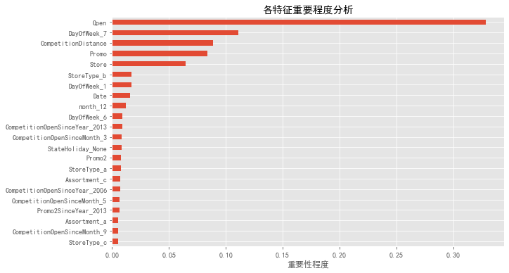

```python
rf = RandomForestRegressor(max_depth = 38,max_features = 0.6,n_estimators = 34)
rf.fit(train_x,train_y)
importance_metrics=pd.Series(rf.feature_importances_,index=train_x.columns).sort_values()
fig=plt.figure(figsize=(10,6))
plt.style.use('ggplot')
ax=fig.add_subplot(1,1,1)
importance_metrics[importance_metrics>0.005].plot.barh(ax=ax)#帅选重要程度超过0.005的
ax.set_xlabel('重要性程度')
ax.set_title('各特征重要程度分析')
plt.show()
```

由上图可以看出最重要的几个特征分别为是否开业，周日是否营业以及竞争者距离和是否促销，与预想的情况吻合